# matplotlib.axes.Axes.plot

**Axes.plot(*args, *scalex=True*, *scaley=True*, *data=None*, **kwargs)[[source]](https://github.com/matplotlib/matplotlib/blob/v3.10.8/lib/matplotlib/axes/_axes.py#L1532-L1784)**

Plot y versus x as lines and/or markers.

Call signatures:

```
plot([x], y, [fmt], *, data=None, **kwargs)
plot([x], y, [fmt], [x2], y2, [fmt2], ..., **kwargs)
```

The coordinates of the points or line nodes are given by *x*, *y*.

The optional parameter *fmt* is a convenient way for defining basic formatting like color, marker and linestyle. It's a shortcut string notation described in the *Notes* section below.

```
>>> plot(x, y)        # plot x and y using default line style and color
>>> plot(x, y, 'bo')  # plot x and y using blue circle markers
>>> plot(y)           # plot y using x as index array 0..N-1
>>> plot(y, 'r+')     # ditto, but with red plusses
```

You can use `Line2D` properties as keyword arguments for more control on the appearance. Line properties and *fmt* can be mixed. The following two calls yield identical results:

```
>>> plot(x, y, 'go--', linewidth=2, markersize=12)
>>> plot(x, y, color='green', marker='o', linestyle='dashed',
...      linewidth=2, markersize=12)
```

When conflicting with *fmt*, keyword arguments take precedence.

**Plotting labelled data**

There's a convenient way for plotting objects with labelled data (i.e. data that can be accessed by index `obj['y']`). Instead of giving the data in *x* and *y*, you can provide the object in the *data* parameter and just give the labels for *x* and *y*:

```
>>> plot('xlabel', 'ylabel', data=obj)
```

All indexable objects are supported. This could e.g. be a [`dict`](https://docs.python.org/3/library/stdtypes.html#dict), a [`pandas.DataFrame`](https://pandas.pydata.org/pandas-docs/stable/reference/api/pandas.DataFrame.html#pandas.DataFrame) or a structured numpy array.

**Plotting multiple sets of data**

There are various ways to plot multiple sets of data.

- The most straight forward way is just to call `plot` multiple times. Example:

  ```
  >>> plot(x1, y1, 'bo')
  >>> plot(x2, y2, 'go')
  ```

- If *x* and/or *y* are 2D arrays, a separate data set will be drawn for every column. If both *x* and *y* are 2D, they must have the same shape. If only one of them is 2D with shape (N, m) the other must have length N and will be used for every data set m.

  Example:

  ```
  >>> x = [1, 2, 3]
  >>> y = np.array([[1, 2], [3, 4], [5, 6]])
  >>> plot(x, y)
  ```

  is equivalent to:

  ```
  >>> for col in range(y.shape[1]):
  ...     plot(x, y[:, col])
  ```

- The third way is to specify multiple sets of *[x]*, *y*, *[fmt]* groups:

  ```
  >>> plot(x1, y1, 'g^', x2, y2, 'g-')
  ```

  In this case, any additional keyword argument applies to all datasets. Also, this syntax cannot be combined with the *data* parameter.

By default, each line is assigned a different style specified by a 'style cycle'. The *fmt* and line property parameters are only necessary if you want explicit deviations from these defaults. Alternatively, you can also change the style cycle using `rcParams["axes.prop_cycle"]` (default: `cycler('color', ['#1f77b4', '#ff7f0e', '#2ca02c', '#d62728', '#9467bd', '#8c564b', '#e377c2', '#7f7f7f', '#bcbd22', '#17becf'])`).

**Parameters:**

**x, y**array-like or float**

The horizontal / vertical coordinates of the data points. *x* values are optional and default to `range(len(y))`.

Commonly, these parameters are 1D arrays.

They can also be scalars, or two-dimensional (in that case, the columns represent separate data sets).

These arguments cannot be passed as keywords.

**fmt**str, optional**

A format string, e.g. 'ro' for red circles. See the *Notes* section for a full description of the format strings.

Format strings are just an abbreviation for quickly setting basic line properties. All of these and more can also be controlled by keyword arguments.

This argument cannot be passed as keyword.

**data**indexable object, optional**

An object with labelled data. If given, provide the label names to plot in *x* and *y*.

Note

Technically there's a slight ambiguity in calls where the second label is a valid *fmt*. `plot('n', 'o', data=obj)` could be `plt(x, y)` or `plt(y, fmt)`. In such cases, the former interpretation is chosen, but a warning is issued. You may suppress the warning by adding an empty format string `plot('n', 'o', '', data=obj)`.

**Returns:**

**list of `Line2D`**

A list of lines representing the plotted data.

**Other Parameters:**

**scalex, scaley**bool, default: True**

These parameters determine if the view limits are adapted to the data limits. The values are passed on to `autoscale_view`.

**kwargs`Line2D` properties, optional**

*kwargs* are used to specify properties like a line label (for auto legends), linewidth, antialiasing, marker face color. Example:

```
>>> plot([1, 2, 3], [1, 2, 3], 'go-', label='line 1', linewidth=2)
>>> plot([1, 2, 3], [1, 4, 9], 'rs', label='line 2')
```

If you specify multiple lines with one plot call, the kwargs apply to all those lines. In case the label object is iterable, each element is used as labels for each set of data.

Here is a list of available `Line2D` properties:

| Property | Description |
| --- | --- |
| `agg_filter` | a filter function, which takes a (m, n, 3) float array and a dpi value, and returns a (m, n, 3) array and two offsets from the bottom left corner of the image |
| `alpha` | float or None |
| `animated` | bool |
| `antialiased` or `aa` | bool |
| `clip_box` | `BboxBase` or None |
| `clip_on` | bool |
| `clip_path` | Patch or (Path, Transform) or None |
| `color` or `c` | [color](https://matplotlib.org/stable/users/explain/colors/colors.html#colors-def) |
| `dash_capstyle` | `CapStyle` or {'butt', 'projecting', 'round'} |
| `dash_joinstyle` | `JoinStyle` or {'miter', 'round', 'bevel'} |
| `dashes` | sequence of floats (on/off ink in points) or (None, None) |
| `data` | (2, N) array or two 1D arrays |
| `drawstyle` or `ds` | {'default', 'steps', 'steps-pre', 'steps-mid', 'steps-post'}, default: 'default' |
| `figure` | `Figure` or `SubFigure` |
| `fillstyle` | {'full', 'left', 'right', 'bottom', 'top', 'none'} |
| `gapcolor` | [color](https://matplotlib.org/stable/users/explain/colors/colors.html#colors-def) or None |
| `gid` | str |
| `in_layout` | bool |
| `label` | object |
| `linestyle` or `ls` | {'-', '--', '-.', ':', '', (offset, on-off-seq), ...} |
| `linewidth` or `lw` | float |
| `marker` | marker style string, `Path` or `MarkerStyle` |
| `markeredgecolor` or `mec` | [color](https://matplotlib.org/stable/users/explain/colors/colors.html#colors-def) |
| `markeredgewidth` or `mew` | float |
| `markerfacecolor` or `mfc` | [color](https://matplotlib.org/stable/users/explain/colors/colors.html#colors-def) |
| `markerfacecoloralt` or `mfcalt` | [color](https://matplotlib.org/stable/users/explain/colors/colors.html#colors-def) |
| `markersize` or `ms` | float |
| `markevery` | None or int or (int, int) or slice or list[int] or float or (float, float) or list[bool] |
| `mouseover` | bool |
| `path_effects` | list of `AbstractPathEffect` |
| `picker` | float or callable[[Artist, Event], tuple[bool, dict]] |
| `pickradius` | float |
| `rasterized` | bool |
| `sketch_params` | (scale: float, length: float, randomness: float) |
| `snap` | bool or None |
| `solid_capstyle` | `CapStyle` or {'butt', 'projecting', 'round'} |
| `solid_joinstyle` | `JoinStyle` or {'miter', 'round', 'bevel'} |
| `transform` | unknown |
| `url` | str |
| `visible` | bool |
| `xdata` | 1D array |
| `ydata` | 1D array |
| `zorder` | float |

See also

**`scatter`**

XY scatter plot with markers of varying size and/or color ( sometimes also called bubble chart).

#### Notes

**Format Strings**

A format string consists of a part for color, marker and line:

```
fmt = '[marker][line][color]'
```

Each of them is optional. If not provided, the value from the style cycle is used. Exception: If `line` is given, but no `marker`, the data will be a line without markers.

Other combinations such as `[color][marker][line]` are also supported, but note that their parsing may be ambiguous.

**Markers**

| character | description |
| --- | --- |
| `'.'` | point marker |
| `','` | pixel marker |
| `'o'` | circle marker |
| `'v'` | triangle_down marker |
| `'^'` | triangle_up marker |
| `'<'` | triangle_left marker |
| `'>'` | triangle_right marker |
| `'1'` | tri_down marker |
| `'2'` | tri_up marker |
| `'3'` | tri_left marker |
| `'4'` | tri_right marker |
| `'8'` | octagon marker |
| `'s'` | square marker |
| `'p'` | pentagon marker |
| `'P'` | plus (filled) marker |
| `'*'` | star marker |
| `'h'` | hexagon1 marker |
| `'H'` | hexagon2 marker |
| `'+'` | plus marker |
| `'x'` | x marker |
| `'X'` | x (filled) marker |
| `'D'` | diamond marker |
| `'d'` | thin_diamond marker |
| `'\|'` | vline marker |
| `'_'` | hline marker |

**Line Styles**

| character | description |
| --- | --- |
| `'-'` | solid line style |
| `'--'` | dashed line style |
| `'-.'` | dash-dot line style |
| `':'` | dotted line style |

Example format strings:

```
'b'    # blue markers with default shape
'or'   # red circles
'-g'   # green solid line
'--'   # dashed line with default color
'^k:'  # black triangle_up markers connected by a dotted line
```

**Colors**

The supported color abbreviations are the single letter codes

| character | color |
| --- | --- |
| `'b'` | blue |
| `'g'` | green |
| `'r'` | red |
| `'c'` | cyan |
| `'m'` | magenta |
| `'y'` | yellow |
| `'k'` | black |
| `'w'` | white |

and the `'CN'` colors that index into the default property cycle.

If the color is the only part of the format string, you can additionally use any `matplotlib.colors` spec, e.g. full names (`'green'`) or hex strings (`'#008000'`).

## Examples using `matplotlib.axes.Axes.plot`

[figure not shown]

[Decay](https://matplotlib.org/stable/gallery/animation/animate_decay.html)

Decay

[figure not shown]

[The Bayes update](https://matplotlib.org/stable/gallery/animation/bayes_update.html)

The Bayes update

[figure not shown]

[The double pendulum problem](https://matplotlib.org/stable/gallery/animation/double_pendulum.html)

The double pendulum problem

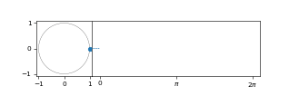

[Multiple Axes animation](https://matplotlib.org/stable/gallery/animation/multiple_axes.html)

Multiple Axes animation

[figure not shown]

[Animated 3D random walk](https://matplotlib.org/stable/gallery/animation/random_walk.html)

Animated 3D random walk

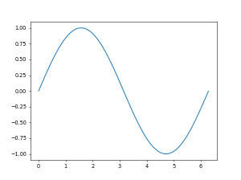

[Animated line plot](https://matplotlib.org/stable/gallery/animation/simple_anim.html)

Animated line plot

[figure not shown]

[Matplotlib unchained](https://matplotlib.org/stable/gallery/animation/unchained.html)

Matplotlib unchained

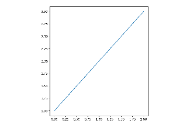

[Axes with a fixed physical size](https://matplotlib.org/stable/gallery/axes_grid1/demo_fixed_size_axes.html)

Axes with a fixed physical size

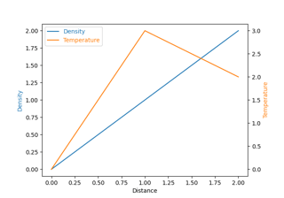

[Parasite Simple](https://matplotlib.org/stable/gallery/axes_grid1/parasite_simple.html)

Parasite Simple

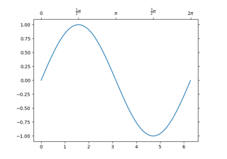

[Simple Axisline4](https://matplotlib.org/stable/gallery/axes_grid1/simple_axisline4.html)

Simple Axisline4

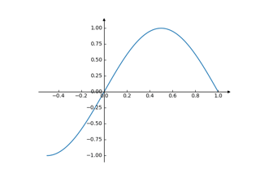

[Axis line styles](https://matplotlib.org/stable/gallery/axisartist/demo_axisline_style.html)

Axis line styles

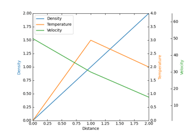

[Parasite Axes demo](https://matplotlib.org/stable/gallery/axisartist/demo_parasite_axes.html)

Parasite Axes demo

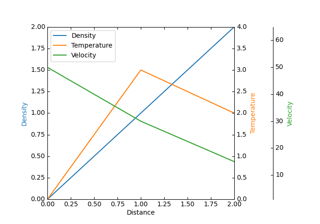

[Parasite axis demo](https://matplotlib.org/stable/gallery/axisartist/demo_parasite_axes2.html)

Parasite axis demo

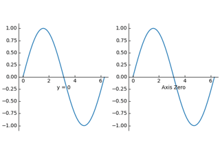

[Custom spines with axisartist](https://matplotlib.org/stable/gallery/axisartist/simple_axisartist1.html)

Custom spines with axisartist

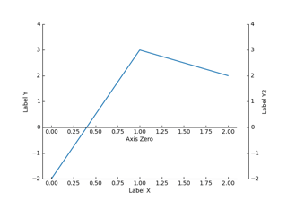

[Simple Axisline](https://matplotlib.org/stable/gallery/axisartist/simple_axisline.html)

Simple Axisline

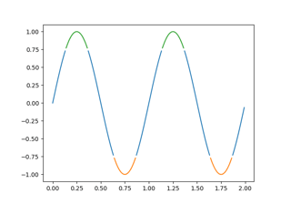

[Color by y-value](https://matplotlib.org/stable/gallery/color/color_by_yvalue.html)

Color by y-value

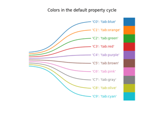

[Colors in the default property cycle](https://matplotlib.org/stable/gallery/color/color_cycle_default.html)

Colors in the default property cycle

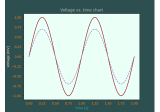

[Color Demo](https://matplotlib.org/stable/gallery/color/color_demo.html)

Color Demo

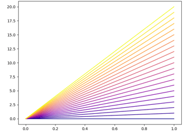

[Selecting individual colors from a colormap](https://matplotlib.org/stable/gallery/color/individual_colors_from_cmap.html)

Selecting individual colors from a colormap

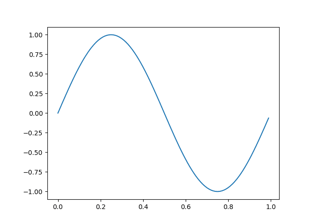

[Mouse move and click events](https://matplotlib.org/stable/gallery/event_handling/coords_demo.html)

Mouse move and click events

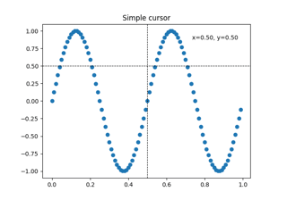

[Cross-hair cursor](https://matplotlib.org/stable/gallery/event_handling/cursor_demo.html)

Cross-hair cursor

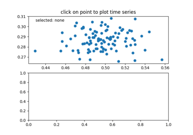

[Data browser](https://matplotlib.org/stable/gallery/event_handling/data_browser.html)

Data browser

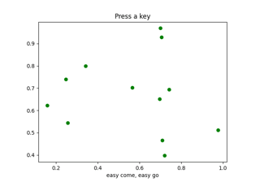

[Keypress event](https://matplotlib.org/stable/gallery/event_handling/keypress_demo.html)

Keypress event

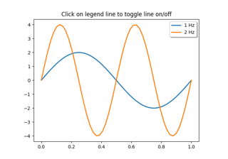

[Legend picking](https://matplotlib.org/stable/gallery/event_handling/legend_picking.html)

Legend picking

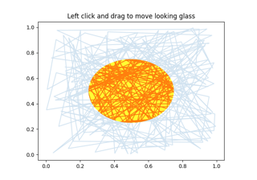

[Looking glass](https://matplotlib.org/stable/gallery/event_handling/looking_glass.html)

Looking glass

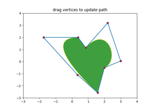

[Path editor](https://matplotlib.org/stable/gallery/event_handling/path_editor.html)